# ds202_hw3

Danny Nguyen

February 19, 2019

```r
data(tips, package="reshape2")
summary(tips)
```

```
##    total_bill         tip             sex      smoker      day
##  Min.   : 3.07   Min.   : 1.000   Female: 87   No :151   Fri :19
##  1st Qu.:13.35   1st Qu.: 2.000   Male  :157   Yes: 93   Sat :87
##  Median :17.80   Median : 2.900                          Sun :76
##  Mean   :19.79   Mean   : 2.998                          Thur:62
##  3rd Qu.:24.13   3rd Qu.: 3.562
##  Max.   :50.81   Max.   :10.000
##      time          size
##  Dinner:176   Min.   :1.00
##  Lunch : 68   1st Qu.:2.00
##               Median :2.00
##               Mean   :2.57
##               3rd Qu.:3.00
##               Max.   :6.00
```

```r
print(tips)
```

[output not shown]

[output cut: 230 more lines]

1. How many parties did the waiter serve? Store the number in numParty and print. If we are referring parties to the number of observations then the number of parties the waiter served was 244.

```r
numParty <- 244
print(numParty)
```

```
## [1] 244
```

2. What are the types of variables in the data frame tips? The types of the variables in the data frame tips are double and integer.

```r
typeof(tips$total_bill)
```

```
## [1] "double"
```

```r
typeof(tips$tip)
```

```
## [1] "double"
```

```r
typeof(tips$sex)
```

```
## [1] "integer"
```

```r
typeof(tips$smoker)
```

```
## [1] "integer"
```

```r
typeof(tips$day)
```

```
## [1] "integer"
```

```r
typeof(tips$time)
```

```
## [1] "integer"
```

```r
typeof(tips$size)
```

```
## [1] "integer"
```

```r
day <- tips$day
print(day)
```

```
##   [1] Sun  Sun  Sun  Sun  Sun  Sun  Sun  Sun  Sun  Sun  Sun  Sun  Sun  Sun
##  [15] Sun  Sun  Sun  Sun  Sun  Sat  Sat  Sat  Sat  Sat  Sat  Sat  Sat  Sat
##  [29] Sat  Sat  Sat  Sat  Sat  Sat  Sat  Sat  Sat  Sat  Sat  Sat  Sat  Sun
##  [43] Sun  Sun  Sun  Sun  Sun  Sun  Sun  Sun  Sun  Sun  Sun  Sun  Sun  Sun
##  [57] Sat  Sat  Sat  Sat  Sat  Sat  Sat  Sat  Sat  Sat  Sat  Sat  Sat  Sat
##  [71] Sat  Sat  Sat  Sat  Sat  Sat  Sat  Thur Thur Thur Thur Thur Thur Thur
##  [85] Thur Thur Thur Thur Thur Thur Fri  Fri  Fri  Fri  Fri  Fri  Fri  Fri
##  [99] Fri  Fri  Fri  Fri  Sat  Sat  Sat  Sat  Sat  Sat  Sat  Sat  Sat  Sat
## [113] Sun  Sun  Sun  Sun  Sun  Thur Thur Thur Thur Thur Thur Thur Thur Thur
## [127] Thur Thur Thur Thur Thur Thur Thur Thur Thur Thur Thur Thur Thur Thur
## [141] Thur Thur Thur Thur Thur Thur Thur Thur Thur Thur Sun  Sun  Sun  Sun
## [155] Sun  Sun  Sun  Sun  Sun  Sun  Sun  Sun  Sun  Sun  Sun  Sun  Sun  Sun
## [169] Sat  Sat  Sat  Sat  Sun  Sun  Sun  Sun  Sun  Sun  Sun  Sun  Sun  Sun
## [183] Sun  Sun  Sun  Sun  Sun  Sun  Sun  Sun  Sun  Thur Thur Thur Thur Thur
## [197] Thur Thur Thur Thur Thur Thur Thur Thur Thur Thur Sat  Sat  Sat  Sat
## [211] Sat  Sat  Sat  Sat  Sat  Sat  Sat  Sat  Sat  Sat  Fri  Fri  Fri  Fri
## [225] Fri  Fri  Fri  Sat  Sat  Sat  Sat  Sat  Sat  Sat  Sat  Sat  Sat  Sat
## [239] Sat  Sat  Sat  Sat  Sat  Thur
## Levels: Fri Sat Sun Thur
```

4. Create a data frame named female5 containing the meal paid by a female payer in a party with size greater than or euqal to 5. Also print the data frame.

```r
female5 <- data.frame(tips$sex == "Female", tips$size >= 5)
print(female5)
```

[output not shown]

[output cut: 230 more lines]

5. How does the tipping amount (tip) depend on the overall bill (total_bill)? Describe the relationship in words. Describe at least two types of anomalies in the plot. What do they mean? Use the ggplot2 package to make a chart. Based on the chart, it seems there is a possible positive correlation between the total_bill and tipping amount. One anomaly is that there seems to be a straight linear trend around the 2 and 3 dollar marks this could be because maybe those are the average tipping amounts. The other anomaly I could tell would be the density of the points, it is a lot more clustered at the lower amounts but more spread out at the higher amounts.

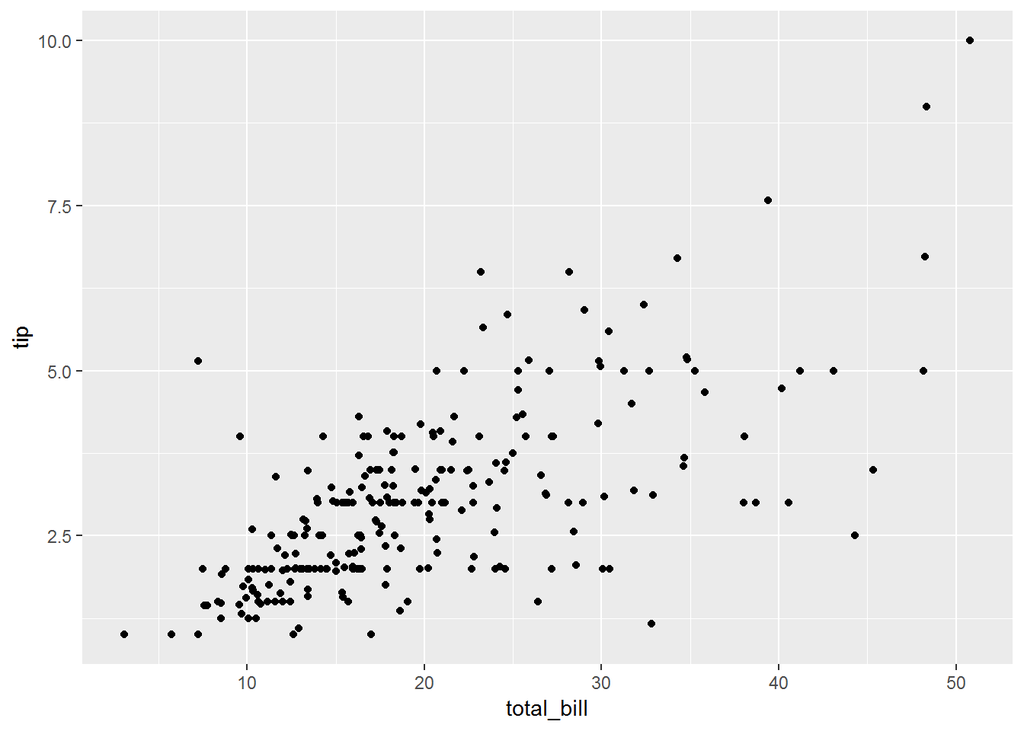

```r
ggplot(data = tips, aes(x = total_bill, y = tip)) + geom_point()
```

6. Introduce a variable tiprate into the data set, that incorporates the rate of tips. What is the average rate for tips?

```r
tiprate <- mean(tips$tip)
print(tiprate)
```

```
## [1] 2.998279
```

[figure not shown]

```r
ggplot(data = tips, aes(x = tiprate, y = time)) + geom_boxplot() + coord_flip()
```

8. How does smoking behavior and gender of the person who pays impact the relationship between tip and total bill? Find a visualization that incorporates all four variables. Interpret the result. Well males and females that don’t smoke seem to be the more frequent tippers, but those that do smoke are more spread out in terms of tipping and total bill.

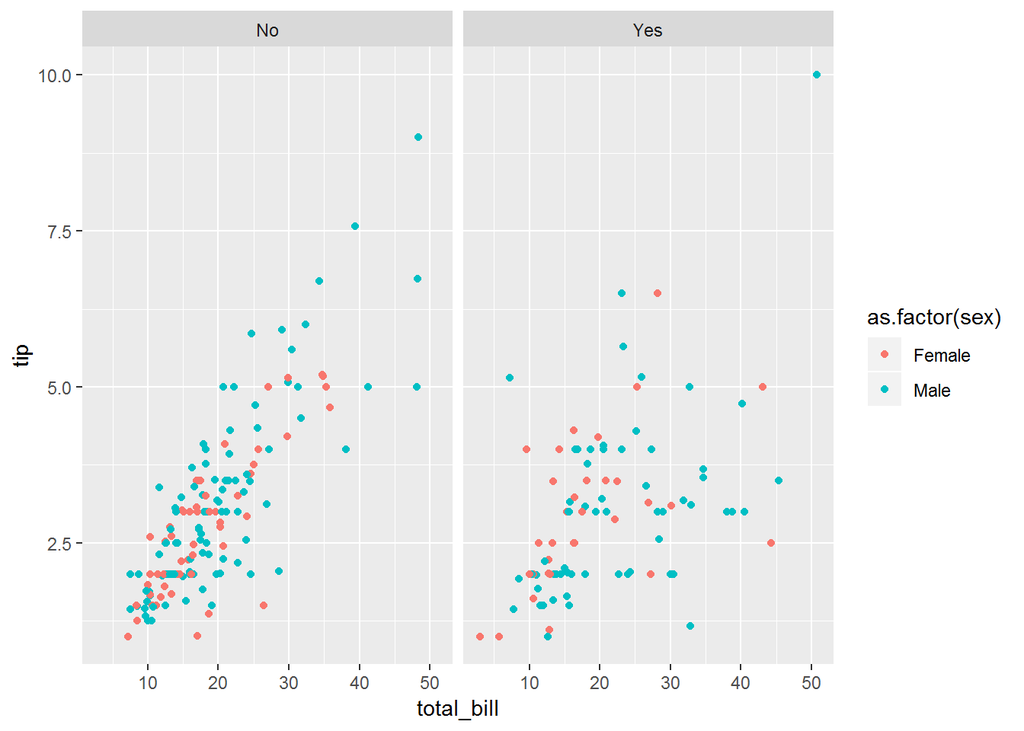

```r
ggplot(data = tips, aes(x=total_bill, y=tip, color=as.factor(sex))) +
  geom_point() +
  facet_grid(. ~ smoker)
```

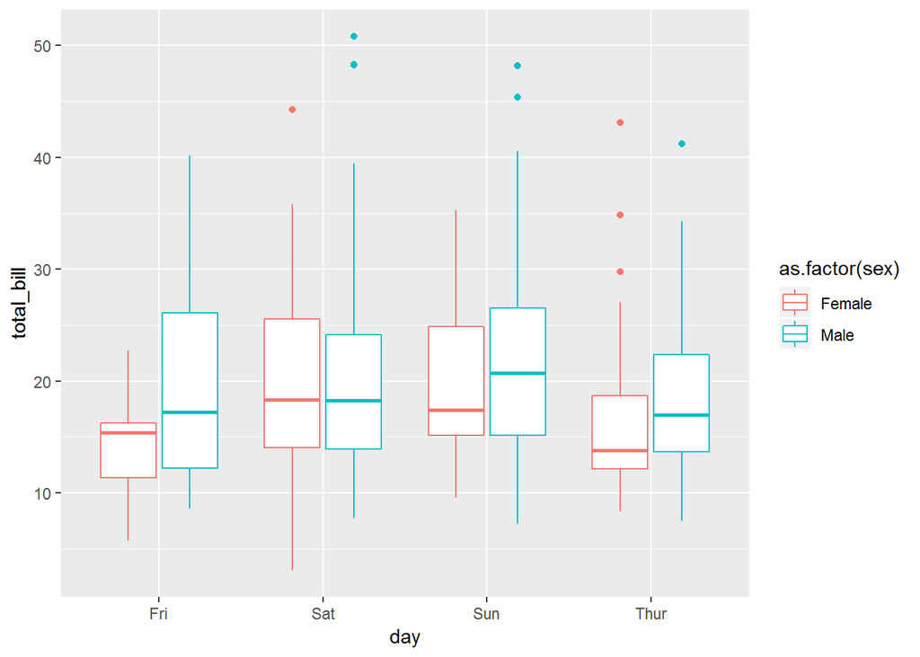

```r
ggplot(data = tips, aes(x=day, y=total_bill, color=as.factor(sex))) +
  geom_boxplot()
```